# 面向蛋白质定向进化的受控科学智能体研究报告

**版本**：v0.4 完备扩充版 ｜ **作者**：Zeyu Li ｜ **日期**：2026-09-12  
**开源代码库**：protein-directed-evolution-agent

## 1 背景与问题定义

### 1.1 蛋白质定向进化的实验流程与计算挑战

蛋白质是执行生命功能的核心生物大分子，其精确的三维空间构象与生化活性由一维氨基酸序列严格决定。在生物制造、合成生物学与基因治疗等尖端工业领域，对天然蛋白质进行工程化改造以提升其催化活性、热稳定性、底物特异性或组织靶向性是长期的核心诉求。传统蛋白质工程主要依赖于定向进化（Directed Evolution）技术，该方法模仿自然进化的“变异-筛选-扩增”机制，通过分子生物学手段对靶标基因进行随机突变或DNA重组，进而在体外进行高通量表型筛选。弗朗西斯·阿诺德（Frances H. Arnold）教授因开创定向进化技术而荣获2018年诺贝尔化学奖，奠定了这一领域的现代实验基石。

然而，传统的湿实验定向进化高度依赖于海量文库筛选，面临着显著的物理与经济限制。近年来，机器学习辅助的定向进化（Machine-Learning-Guided Directed Evolution, MLDE）逐渐成为主流前沿[[1]](https://doi.org/10.1038/s41592-019-0496-6)。早期的探索采用DNA重组技术（DNA Shuffling）[[2]](https://doi.org/10.1038/370389a0)或迭代饱和突变（Iterative Saturation Mutagenesis, ISM）[[3]](https://doi.org/10.1038/nprot.2007.72)来缩小实验搜索空间，通过在预设的有益热点残基位点实施饱和突变，以系统性组合优良表型。随着深度学习与蛋白质语言模型的爆发式演进，计算生物学界面临着一个更高维度的命题：如何利用算法构建数字闭环，替代或指导耗时费力的物理湿实验，实现少样本乃至零样本条件下的高效序列设计与全局寻优？

### 1.2 组合爆炸难题与高维离散适应度景观

蛋白质设计的首要数学障碍在于序列空间的离散组合爆炸。蛋白质由 20 种天然氨基酸排列组合而成，对于一个具有 $L$ 个突变候选位点的蛋白质区域，其理论序列组合空间大小呈指数级增长：
$$|\mathcal{X}| = 20^L$$
对于仅涉及 4 个突变位点的 GB1 蛋白局部改造，其理论序列空间为 $20^4 = 160,000$ 种可能；而对于涉及 28 个氨基酸窗口的 AAV2 腺相关病毒衣壳突变区，理论全组合空间高达 $20^{28} \approx 2.68 \times 10^{36}$ 种可能。这一天文数字远远超出了人类全部湿实验通量的物理承载极限。

更为严峻的是，蛋白质的“序列-功能”映射关系构成了高度复杂、非凸且崎岖的高维适应度景观（Fitness Landscape）。在能量面上，残基之间存在着复杂的非加性相互作用（即上位效应，Epistasis）。单个突变可能在某一遗传背景下具有破坏性，但在与其他互补突变共同存在时却可能形成协同稳定的分子内相互作用网络。这种高度非线性的拓扑结构导致适应度景观布满了大量的局部次优峰（Local Optima）和较为平坦的适应度鞍点（Fitness Saddles），传统的局部爬山算法或简单的贪心搜索极易陷入局部陷阱，无法跃迁至全局高适应度峰值。

### 1.3 虚拟定向进化实验协议与预算隔离机制

为了在可控的计算环境中严格评估不同算法、代理模型与智能体策略在定向进化任务中的真实寻优效率，本研究构建了标准化的“虚拟定向进化”（Virtual Directed Evolution）评测协议。该协议以高通量实验测定的真实突变文库为“底层虚拟湿实验机（Virtual Wet-lab Oracle）”，严格模拟实验室中真实的“设计-合成-测定-学习”（DBTL）多轮迭代闭环。

形式化地，设全量已测变体集合为 $\mathcal{D} = \{(x_i, y_i)\}_{i=1}^N$，其中 $x_i \in \mathcal{A}^L$ 表示长度为 $L$ 的氨基酸序列（$\mathcal{A}$ 为 20 种天然氨基酸字母表），$y_i = f(x_i) \in \mathbb{R}$ 表示实验测定的标量适应度值（如结合自由能变化、荧光强度或病毒包装滴度）。我们将整个实验闭环严格定义如下：

1. **冷启动初始已测集（$M_0$）**：系统在第 0 轮仅能观测到有限的低阶突变变体集合 $M_0 \subset \mathcal{D}$（通常限制汉明距离 $d_H(x, x_{\rm wt}) \le 2$），模拟真实实验室刚起步时仅掌握单突变或少量双突变的低资源情境；
2. **未测候选序列池（$Q_0$）**：所有待探索的高阶突变序列构成未测候选池 $Q_0 = \mathcal{D} \setminus M_0$。在实验推进过程中，所有候选序列的真实适应度标签 $y$ 对搜索智能体、代理模型及设计策略均严格不可见（Oracle 隔离）；
3. **批次采样与状态转移（$B_t$）**：在每一实验轮次 $t = 1, 2, \dots, T$，智能体根据当前累积掌握的数据集 $M_{t-1}$ 拟合代理模型并调用采集策略，在固定预算约束（Batch Budget $K$）下从剩余候选集 $Q_{t-1}$ 中提名一个批次 $B_t \subset Q_{t-1}$（$|B_t| = K$）；
4. **测量冻结与账本追加**：批次 $B_t$ 经系统校验冻结后，提交至底层虚拟 Oracle 揭晓对应真实适应度，随后状态集按定义严格更新：
   $$\begin{aligned}
   M_t &= M_{t-1} \cup B_t, \\
   Q_t &= Q_{t-1} \setminus B_t
   \end{aligned}$$
5. **性能评价度量**：分别统计新增测量序列的累计最大适应度 $f_{\rm new}(T) = \max_{x \in \bigcup_{t=1}^T B_t} f(x)$、包含冷启动的全局累计最佳值 $f_{\rm all}(T) = \max_{x \in M_T} f(x)$、超过工程阈值的强变体产出数（Strong Variants Yield）以及首次捕获峰值的批次轮数。

在整个协议执行期间，系统严禁对任何序列进行跨轮次重复查询，严格保障每一批次预算的物理有效性。

### 1.4 搜索目标设定与工程评价基准讨论：9.536 现象分析

在展开算法对比之前，需要明确实验探索的目标定义与评价基准。在 AAV2 衣壳蛋白的优化任务中，存在一个值得关注的现象（本研究称为“9.536 现象”）： 在冷启动初始已知数据集 $M_0$（10,433 条变体）中，实际已经包含了一条具有高适应度分数的双突变序列 `DEEEIRTTNPVATEQYGSYSTNLQQGNR`（$d_H=2$，真实适应度为 $9.53645667$）；而整个未测高阶突变候选池 $Q_0$（27,832 条高阶变体，包括全部三突变及更高阶变体）中的理论全局最高值，是由三突变序列 `QEEEIRTTNPVATEQYGEASTNLQRGNR`（$d_H=3$）所保持的 $8.41620513$。

这一现象引发了关于搜索目标设定的思考： 若在未测池 $Q_0$ 中通过建模与优化找到了候选池的最高峰 $8.4162$，但从全局视角来看，该峰值仍低于冷启动已知库中已存在的 $9.5365$。这是否意味着进一步探索高阶突变缺乏实际意义？ 答案是否定的，这体现了实际生物工程优化与单目标基准寻优之间的差异：

1. **多目标协同与上位性折叠崩溃的客观物理现实**：在真实的蛋白质分子工程中，提高单一功能适应度只是初级目标。当突变位点增加时，由于残基之间的上位性冲突，蛋白质构象发生局部崩溃或去折叠的概率急剧上升。但在药物开发与工业酶设计中，我们往往需要同时满足 3~4 种甚至更多严苛属性（如高催化活性、高热熔解温度 Tm、低免疫原性、抗蛋白酶水解能力以及高效表达量）。两个点位的突变或许能将单一指标推向高位（9.536），但往往难以同时兼顾多维度的工程指标。在实际工程中通常需要在多个位点进行协同重构，才能在保持活性的同时兼顾热稳定性与低免疫原性等多目标要求。
2. **面对未知搜索空间的认知对齐**：在未掌握全量标签的真实实验场景中，实验人员无法预知未测高阶突变池中是否存在高于已知样本的变体。评价一个搜索算法或智能体系统，不仅要看其最终极值，更要评估其在面对未知候选空间时，能否有效识别潜在模式、跳出局部陷阱并稳定收敛到高价值区域。

### 1.5 目标驱动停止准则（Target-Driven Stopping）与信息期望价值（EVI）

基于上述分析，本研究提出一项实用的工程原则：**定向进化搜索可采用“目标驱动停止”（Target-Driven Stopping），避免无收益的盲目迭代**。

在实际工业研发中，只要某一工程变体在置信度要求下满足了临床或产业要求的性能契约阈值向量 $\boldsymbol{\tau} = (\tau_1, \tau_2, \dots, \tau_m)^\top$，研发团队就应当理性收工，转入下游工艺放大阶段。形式化地，设待评估候选变体 $x$ 的多项性能指标预测分布为 $F_j(x)$，经独立的确认性测量 $\mathcal{D}_{\rm confirm}$ 后，停止准则可定义为：
$$\begin{aligned}
\mathbb{P}\Big( &F_j(x) \ge \tau_j, \; \forall j \in \{1, \dots, m\}
\\
&\;\Big|\; \mathcal{D}_{\rm confirm} \Big) \ge 1 - \alpha
\end{aligned}$$
其中 $\alpha$ 为预设的风险容忍度（例如 $\alpha = 0.05$）。

从决策论与信息经济学视角，进一步引入批次实验的信息期望价值（Expected Value of Information, EVI）：
$$\begin{aligned}
\operatorname{EVI}(B_t) &= \mathbb{E}_{Y_{B_t} \mid
\mathcal{D}_{t-1}} \left[ \max_{a \in \mathcal{A}} \mathbb{E}[U(a, F)
\mid \mathcal{D}_{t-1}, Y_{B_t}] \right] \\
&\quad - \max_{a \in \mathcal{A}} \mathbb{E}[U(a, F) \mid
\mathcal{D}_{t-1}]
\end{aligned}$$
当且仅当该批次带来的预期决策增益 $\operatorname{EVI}(B_t)$ 严格低于开展该批次物理合成与测序的边际经济成本 $c(B_t)$ 时（即 $\operatorname{EVI}(B_t) \le c(B_t)$），系统应当触发自动终止判定。这种基于决策效用的停止机制，为实验探索提供了清晰的终止依据，避免了无收益的持续试错开销。

## 2 数据集介绍

### 2.1 GB1 蛋白 G 结构域四位点全组合突变景观

蛋白质 G 结构域 B1（Protein G domain B1, 简称 GB1）是免疫球蛋白结合蛋白，因其分子量小（56 个氨基酸残基）、构象稳定且耐受突变，成为计算生物学与适应度景观研究的“金标准”基准分子。本研究所采用的数据集源自吴等（Wu et al.）2016 年发表于 *eLife* 的经典实验[[4]](https://doi.org/10.7554/elife.16965)。

在该实验中，作者对 GB1 蛋白中的 4 个关键相互作用位点进行系统性组合饱和突变：第 39 位天冬酰胺/缬氨酸（V39）、第 40 位天冬氨酸（D40）、第 41 位甘氨酸（G41）以及第 54 位缬氨酸（V54）。这四个位点在三维空间中形成一个紧密交织的相互作用核心，野生型序列为 `VDGV`，其实测结合适应度归一化为 1.000。 理论上，4 个位点的饱和突变空间为 $20^4 = 160,000$ 种变体组合。然而在真实的深层测序数据中，该数据集共完整记录了 **149,361 条有效测量变体**，其中存在 **10,639 条天然缺失的测量盲区**（主要是由于 PCR 扩增偏好性、高通量测序覆盖不足或深度缺失所致）。 在本研究的系统实现中，我们坚守学术严谨性，**对这 10,639 条缺失变体严格保持空缺，坚决杜绝任何人工伪造、插值或填补真实标签的非科学行为**。所有算法的候选提名与效果评估，严格限定在这 149,361 条真实测定的序列子集内进行。

### 2.2 AAV2 衣壳蛋白 28 氨基酸高突变文库

为了检验智能体在大规模、长跨度、高突变阶数复杂场景下的拓展寻优能力，本研究引入了布莱恩特等（Bryant et al.）2021 年发表于 *Nature Biotechnology* 的腺相关病毒（Adeno-Associated Virus, AAV）衣壳蛋白深度多样化突变数据集[[5]](https://doi.org/10.1038/s41587-020-00793-4)。

AAV 是当前临床基因治疗领域应用最广泛的病毒载体之一，其衣壳蛋白表面环区（Variable Loop regions）直接决定了病毒的组装包装效率、组织向性（Tropism）以及宿主中和抗体的逃逸能力。该数据集针对 AAV2 衣壳蛋白上一个长达 28 个氨基酸的核心功能窗口（残基编号以窗口 0-基准编号，对应野生型基序 `DEEEIRTTNPVATEQYGSVSTNLQRGNR`）展开深度多样化突变与包装功能适应度定量检测。 数据集中总共包含 **38,265 条** 经过严格质量过滤的有效变体序列。根据本研究的受控评测协议，我们将数据集划分如下： - **低阶冷启动初始库（$M_0$）**：包含汉明距离 $d_H(x, x_{\rm wt}) \le 2$ 的全部已知变体，共计 **10,433 条**（含 WT、单突变体及部分双突变体）； - **高阶未测探索候选池（$Q_0$）**：包含汉明距离 $d_H(x, x_{\rm wt}) > 2$ 的全部高阶突变变体，共计 **27,832 条**。在引入初步的理化与突变阶数门禁后，核心有效候选池包含 **9,533 条** 高价值序列。

### 2.3 国际基准对比与评测协议边界

在国际计算生物学基准体系中，针对蛋白质适应度景观推断，最著名的两大官方基准平台为： 1. **FLIP（Functionality Landscapes of Inferred Proteins）**[[6]](https://datasets-benchmarks-proceedings.neurips.cc/paper_files/paper/2021/file/2b44928ae11fb9384c4cf38708677c48-Paper-round2.pdf)：NeurIPS 2021 推出的标准化基准，重点关注在低资源、高突变阶数外推等场景下的回归预测泛化性能； 2. **ProteinGym**[[7]](https://proceedings.neurips.cc/paper_files/paper/2023/hash/cac723e5ff29f65e3fcbb0739ae91bee-Abstract-Datasets_and_Benchmarks.html)：NeurIPS 2023 推出的囊括 200 余个湿实验深度突变扫描（DMS）测定的超大规模统一评测基准。

此外，萨尔基相等（Sarkisyan et al.）在绿色荧光蛋白（GFP）上的局部适应度景观实验表明，复杂的非加性相互作用在天然大分子中广泛存在，其规律必须结合具体的分子物理化学环境进行针对性建模[[8]](https://doi.org/10.1038/nature17995)。

在此需要说明评测边界：**本研究构建的是多轮交互式“虚拟定向进化批次寻优评测协议”，其评估核心是算法在有限轮次与预算内的主动探索与累积发现效率，不直接等同于 FLIP 或 ProteinGym 官方的纯静态回归基准打分**。两者在问题定义、数据划分与评估目标上具有明确的区别。

本研究所采用的数据集基准与实验协议配置详见本章末表 1。

### 2.4 数据清洗、表征规范与防泄漏审计协议

为了确保计算全流程的严谨可复现性，本研究制定了严格的数据工程处理规范： 1. **序列合法性与基序对齐校验**：所有氨基酸序列严格校验长度一致性与 20 种天然氨基酸代码字母表合法性，剔除任何包含非标准氨基酸（如 `X`、`B`、`Z`）或提前终止密码子（`*`）的异常序列； 2. **相对窗口与全蛋白坐标隔离**：严格保持 AAV2 28 位点窗口的相对编号系统（0 至 27），正文中涉及的突变标注（如 D0Q、S17E、V18A）均基于该测定窗口，杜绝将局部坐标误传为病毒全长 VP1 衣壳蛋白绝对坐标的混淆行为； 3. **数据哈希指纹与防篡改追踪**：对原始输入文件生成不可逆的 SHA-256 校验哈希指纹（GB1 manifest 与 AAV manifest），并将数据子集划分清单以结构化 JSON 文件形式固化于本地数据账本中； 4. **Oracle 物理隔离防护**：底层真实适应度查询函数（`OracleLookup`）通过沙箱机制进行逻辑隔离，模型训练、超参数调优及特征提取阶段仅能访问 $M_{t-1}$ 的特征与标签，候选池 $Q_{t-1}$ 的真实标签仅在当前轮次批次提名完全冻结后由评测内核一次性原子解锁。

**表 1：数据集基准与实验协议配置**

| 数据集与评测协议 | 初始已知集合（$M_0$） | 可探索候选池（$Q_0$） | 野生型基序与基准说明 | 库内关键特征变体 |
| --- | --- | --- | --- | --- |
| **GB1 低阶冷启动（LLM 评测）** | $d_H \le 2$ 共 2,168 条 | 147,193 条未测高阶变体 | WT: `VDGV` ($y=1.000$) | 理论最高峰 `FWAA` ($y=8.761966$) |
| **GB1 随机冷启动对照** | 随机采样 5,000 条 | 剩余 144,361 条变体 | 独立对照组，不可与低阶曲线混淆 | 用于评估随机背景下的学习效率 |
| **AAV2 统一预算协议** | $d_H \le 2$ 共 10,433 条 | $d_H > 2$ 共 27,832 条（门内 9,533 条） | WT: `DEEEIRTTNPVATEQYGSVSTNLQRGNR` | 冷启动已知最优: `..YSTNLQQGNR` ($9.5365$)；候选池真峰: `..GEASTNLQRGNR` ($8.4162$) |

## 3 适应度预测模型

### 3.1 适应度预测模型多层次梯队体系

为了在低资源及冷启动条件下准确刻画蛋白质序列与适应度之间的复杂非线性关系，本系统设计了多层次梯队的适应度代理预测模型（Surrogate Model Ladder），涵盖从经典的统计学习方法到前沿的大规模蛋白质语言模型表征。

模型梯队的设计兼顾了计算效率、可解释性与对高阶非加性效应的外推能力：

1. **L1 线性基线：One-hot 编码 + Ridge 岭回归**[[9]](https://doi.org/10.1080/00401706.1970.10488634)
   将序列中每一个位置的残基映射为 20 维的 One-hot 独热向量，长度为 $L$ 的序列被展开为 $20 \times L$ 维的离散特征向量 $\mathbf{x} \in \{0, 1\}^{20L}$。通过引入 $L_2$ 范数正则化项，求解参数权重 $\mathbf{w}$：
   $$\min_{\mathbf{w}} \|\mathbf{y} - \mathbf{\Phi} \mathbf{w}\|_2^2 +
   \lambda \|\mathbf{w}\|_2^2$$
   该模型作为纯加性假设下的极速强基线，具有严格的凸优化解析解，无过拟合随机性，计算开销低。
2. **L2 非线性集成：梯度提升决策树（GBDT / Tree Boosting）**[[10]](https://doi.org/10.1214/aos/1013203451)  
   基于决策树集成的非线性拟合方法，能够自适应捕获特征之间的阶梯阈值切分与局部高阶交叉效应，对特征尺度的缩放具有天然的不变性。
3. **针对性训练集优化与低样本泛化**[[11]](https://doi.org/10.1016/j.cels.2021.07.008)  
   在实际的机器学习引导定向进化中，训练集的构成分布对下游代理模型的泛化界具有决定性影响，必须防范数据分布偏移带来的表征崩塌。
4. **L3 预训练进化表征：蛋白质语言模型 ESM-1 与 ESM-2 650M**[[12]](https://doi.org/10.1073/pnas.2016239118)[[13]](https://doi.org/10.1126/science.ade2574)  
   利用在大规模全生物演化序列数据库（如 UniRef50）上通过掩码语言建模（Masked Language Modeling, MLM）无监督预训练得到的超大规模蛋白质语言模型。ESM-2（6.5 亿参数版本 `esm2_t33_650M_UR50D`）的注意力头中自发涌现出了蛋白质的二级结构、三维接触图以及进化共变模式。我们提取模型倒数第一层的全局表征向量（1280 维嵌入），作为下游回归器的密集物理语义输入。
5. **低样本工程与深度生成模型迁移**[[14]](https://doi.org/10.1038/s41592-021-01100-y)[[15]](https://doi.org/10.1038/s41586-021-04043-8)  
   文献表明，基于进化先验的低样本深度学习（Low-N Engineering）与变分自编码器（EVE）等深层生成模型，能够在仅有少量实验样本的情况下推断致病突变与功能增益突变，为代理模型在远距离突变上的置信度打分提供了强有力的理论支撑。

### 3.2 跨突变阶数（HD Extrapolation）外推性能对比实测

在蛋白质定向进化中，最关键也是最艰巨的挑战在于“突变阶数外推”（Hamming Distance Extrapolation）——即在仅见过低突变阶数（$d_H \le 2$）训练样本的前提下，模型能否准确预测从未见过的多突变阶数（$d_H \ge 3$）高阶变体的相对优劣？

系统在 GB1 数据集上对不同表征方式与回归器组合进行的留出集评测（Spearman 秩相关系数，保留三位小数）详见本章末表 2。从实测对比矩阵中可以观察到： - 在常规的“随机数据划分”场景下，离散的 One-hot Ridge 回归（Spearman=0.484）与预训练 ESM-2 模型（Spearman=0.493）的性能差距较小，传统线性模型凭借高计算性价比表现良好； - 然而，在进行具有挑战性的“跨阶外推”（利用低阶数据训练，测试 $d_H \ge 3$ 的高突变体）时，纯 One-hot 模型的泛化能力明显下降（Ridge 降至 0.358，MLP 降至 0.278）； - 与之形成鲜明对比的是，搭载 ESM-2 深度进化语义嵌入的 MLP 模型，在跨阶外推集上依然取得了 **0.493** 的最高排名相关性（不仅完全没有退化，保持了较好的非线性排序保真度）。这充分证明了大规模自监督蛋白质语言模型所学习到的深层进化先验，能够真正弥补实验低阶数据对高阶构象认知的不足。

### 3.3 高阶上位效应（Epistasis）建模与非线性几何

天然蛋白质的适应度绝非单点突变效应的简单线性叠加。大量序列共变分析[[16]](https://doi.org/10.1038/nbt.3769)与生物物理上位性实验[[17]](https://doi.org/10.1038/s41467-019-12130-8)表明，氨基酸之间的相互作用决定了折叠自由能与催化微环境。

在数学形式上，纯加性独立位点假设将序列 $x = (x_1, \dots, x_L)$ 的预测值表示为一阶线性展开：
$$\hat{f}_{\rm additive}(x) = b + \sum_{i=1}^L h_i(x_i)$$
在此模型下，任何一个位点突变的影响完全独立于其他位点的残基状态。当系统尝试拓展至具有强互作特征的复合突变时，加性模型完全无法捕获位点对之间的空间接触与电荷协同，导致其预测曲面沦为一个平坦无弯曲的刚性超平面。

为了克服这一内在表征缺陷，系统进一步构建了显式成对上位性回归模型（Pairwise Epistatic Model）：
$$\hat{f}_{\rm pairwise}(x) = b + \sum_{i=1}^L h_i(x_i) + \sum_{1 \le i
< j \le L} J_{ij}(x_i, x_j)$$
其中 $J_{ij}(a, b)$ 为位点 $i$ 的氨基酸 $a$ 与位点 $j$ 的氨基酸 $b$ 之间的成对协同耦合项。在几何拓扑上，成对耦合项为高维离散超立方体上的能量面赋予了局部的二次曲率，使得模型具备了刻画非线性协同与局部能量凹陷（鞍点）的数学容量。后续在第 7 节中，我们将结合真实的 AAV 实验变体与图 3 的上位能量面几何，深入剖析当关键二阶过渡变体缺测时，模型所遭遇的可识别性危机。

### 3.4 贝叶斯不确定性度量与采集函数设计

在主动学习与定向进化批次采样中，仅仅依赖适应度预测均值（Exploitation）极易导致搜索迅速陷入局部次优峰。为了实现科学的“探索-利用”（Exploration vs. Exploitation）动态权衡，必须对模型在未知序列空间中的认知不确定性（Epistemic Uncertainty）进行严谨量化。

在经典的贝叶斯优化（Bayesian Optimization）框架中，高斯过程上置信界（GP-UCB）理论提供了严格的无遗憾界分析[[18]](https://doi.org/10.1109/tit.2011.2182033)，而期望提升（Expected Improvement, EI / EGO）[[19]](https://doi.org/10.1023/a:1008306431147)则以封闭积分形式量化了跨越当前已知最佳值的期望增益。 在本系统的工程实现中，由于全量 AAV 候选池（近 3 万条序列）每次调用高斯过程核矩阵的计算开销为 $\mathcal{O}(N^3)$，我们采用高效且稳健的多模型 Bootstrap 深度集成架构来近似后验分布。 对于任意候选变体 $x$，系统基于多个独立重采样子模型（Bootstrap Models with Seeds 0, 1, 2…）输出的预测集合进行统计度量：
$$\begin{aligned}
\hat{\mu}_t(x) &= \frac{1}{M} \sum_{m=1}^M \hat{f}_t^{(m)}(x), \\
\hat{v}_t(x) &= \frac{1}{M-1} \sum_{m=1}^M \left( \hat{f}_t^{(m)}(x)
- \hat{\mu}_t(x) \right)^2
\end{aligned}$$
相应的采集函数（Acquisition Function）定义为 UCB 变体：
$$a_t(x) = \hat{\mu}_t(x) + \beta \sqrt{\hat{v}_t(x)}$$
其中超参数 $\beta \ge 0$ 为探索偏好权重。当 $\beta = 0$ 时，算法退化为激进的纯均值贪心策略（Pure Exploitation）；当 $\beta > 0$ 时，算法主动对模型分歧大、覆盖不确定的潜在盲区进行定向采样加权。后文的消融实验将揭示，$\beta$ 的参数选择直接决定了系统能否穿越由未测突变造成的平坦鞍点。

**表 2：GB1 跨突变阶数外推性能留出集评测对比（Spearman 秩相关系数）**

| 特征表征 × 划分方式 | Ridge 岭回归 | GBDT 梯度提升树 | 深度 MLP 集成 |
| --- | --- | --- | --- |
| **One-hot 编码 × 随机划分 (Random Split)** | 0.484 | 0.474 | 0.389 |
| **ESM-2 650M 嵌入 × 随机划分 (Random Split)** | 0.493 | 0.377 | 0.491 |
| **One-hot 编码 × 跨阶外推 (HD≥3 Extrapolation)** | 0.358 | 0.354 | 0.278 |
| **ESM-2 650M 嵌入 × 跨阶外推 (HD≥3 Extrapolation)** | 0.404 | 0.352 | **0.493** |

## 4 LLM Agent 设计

### 4.1 五角色专业化分工协作体系

大语言模型（LLM）在化学发现工具增强[[20]](https://doi.org/10.1038/s42256-024-00832-8)、自主化学实验编排[[21]](https://doi.org/10.1038/s41586-023-06792-0)以及早期机器人科学家系统（如 Adam）[[22]](https://doi.org/10.1126/science.1165620)中已展现出强大的自然语言理解与符号规划潜能。然而，若将定向进化选样过程完全交付给无约束的端到端 LLM，模型在处理微观数值打分、排列组合约束与分子理化规则时易出现偏差，甚至生成在生物学上难以折叠或存在显著位阻冲突的序列。

为此，本研究提出了“**受控科学智能体双闭环架构**”（Controlled Scientific Agent Architecture）。该系统将整个科研决策流程拆解为五个高度专业化的功能角色，仅在需要非平凡科学推理的关键环节引入受控 LLM 接口，其余所有数值计算、特征矩阵变换、候选去重与硬门禁拦截均由确定性代码核心接管。

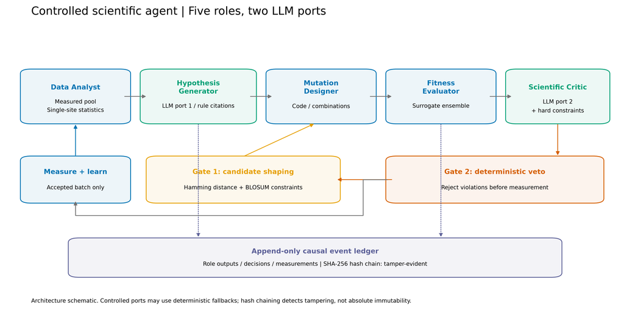

图 1：面向蛋白质定向进化的受控五角色科学智能体双闭环架构

五大角色的详细职责界定如下：

1. **Data Analyst（实验数据分析师）**：对上一轮及历史累积的全部已测变体 $M_{t-1}$ 进行系统性数理统计，计算每个突变位点的单残基保守度、突变偏好频率、均值提升幅度以及理化分布偏移，生成结构化实验现状摘要（Markdown 数据简报）；
2. **Hypothesis Generator（科学假说生成器，LLM 接口 1）**：作为系统的外环发散思考枢纽，结合数据简报与先验规则库，提出具备明确生物物理机理解释的可检验假设（如：“位点 17 引入带负电荷的天冬氨酸/谷氨酸，有望与空间邻近的正电荷残基形成稳定盐桥”）；
3. **Mutation Designer（突变序列设计器）**：接收假说模板，在代码层调用组合生成算法，将假说约束映射为具体的候选序列集合，完成与野生型基序的对齐校验与全集查重；
4. **Fitness Evaluator（适应度评估器）**：调用底层代理模型梯队，对生成的候选序列进行批量前向推断，输出预测适应度均值 $\hat{\mu}(x)$ 与集成不确定性方差 $\hat{v}(x)$，并结合 UCB 策略完成初级候选池排序；
5. **Scientific Critic（科学批判与审查者，LLM 接口 2）**：在候选批次正式下达之前实施严苛的反思审查。批判者依据结构化提示词逐一审视候选理由是否合理、突变位点是否过度集中、是否存在潜在理化冲突，并对存疑变体出具否决建议。

### 4.2 双重物理与理化先验门禁机制

为了确保进入评测阶段的每一条候选变体均符合基础的生物分子物理现实，系统构建了两道严密的确定性门禁防护网： - **Gate 1：候选塑形门禁（Candidate Shaping）**  
在假说生成与序列初筛阶段介入，强制施加汉明距离硬上限（例如 $d_H \le 4$），防止序列在缺乏充分先验时盲目突变至远距离未知区域；同时结合 BLOSUM 替代相容性分数，剔除空间位阻冲突明显或理化性质不相容的不稳定替换。 - **Gate 2：确定性一票否决门禁（Deterministic Hard Veto）**  
在批次提交虚拟 Oracle 之前的最后道关卡，由确定性 Python 脚本执行全覆盖审查。任何包含非法字符、终止密码子、净电荷突变超过极限阈值或破坏已知必需结合基序的变体，均被直接剥夺提名资格，并由备选池中的高置信度变体顺序补位。

### 4.3 结构化数据契约与不可篡改因果审计账本

为了实现科学发现过程的“端到端完全可复现”与“因果可追溯”，系统全面引入了强类型数据契约与不可篡改事件日志机制：

1. **Pydantic 强类型 Schema**：所有智能体角色之间的输入输出通信，均通过显式的 Pydantic 数据模型定义（如 `BatchProposalContract`、`HypothesisDecisionRecord` 等）。任何不符合 JSON Schema 规范的字段或松散格式均会被即时拦截并触发类型修复重试；
2. **不可篡改因果审计账本（Append-only Causal Ledger）**：整个定向进化生命周期中产生的每一个事件（包括模型权重更新、LLM 原始思考链、候选评分明细、门禁拦截记录与 Oracle 实测回执），均按时间顺序追加写入基于 SHA-256 密码学哈希链的持久化账本中。每一个事件节点的哈希值均依赖于其上一节点的摘要：
   $$H_k = \operatorname{SHA-256}(H_{k-1} \,\|\, \operatorname{Payload}_k)$$
   系统内置的 `verify_ledger()` 审计工具能够在毫秒级内自检整个运行轨迹的完整性，一旦发生任何中间状态的人工篡改或数据穿越泄露，哈希链将立即断裂并精准定位异常节点。

### 4.4 大模型在科学工作流中的真正定位与认知边界

在系统研发与实验迭代过程中，我们对大语言模型在序列设计中的能力边界进行了实测评估。若直接让 LLM 作为微观数值优化器（例如让大模型阅读数十条序列后输出预测分数或挑选最优单点突变），在连续数值与高维空间中表现出明显的效率局限： - **微观层面：LLM 不擅长连续微积分与精确数值回归**。在微观参数选样步上，LLM 缺乏显式的数值梯度与凸优化收敛保证，其输出容易受到上下文提示与自回归采样随机性的影响，其稳定性不及确定性数学公式（如 UCB、EI 或高斯过程）； - **宏观层面：LLM 适于承担外环流程调度与假说生成**。LLM 的核心优势在于跨领域知识关联、自然语言归因反思以及宏观实验方案设计。大模型更适于部署在系统的“外环”（Outer-Loop），负责归因分析、文献对比以及实验参数宏观调优；而将“内环”（Inner-Loop）微观连续打分与候选排序的任务交给确定性算法。

## 5 知识增强方法

### 5.1 生物物理理化规则库与氨基酸替代矩阵

天然氨基酸具有鲜明的生物物理化学属性差异，包括侧链体积空间位阻、疏水亲水特性、电荷极性以及形成二级结构（$\alpha$-螺旋、$\beta$-折叠）的倾向。将这些基础物理化学先验注入智能体决策链条，是防止盲目随机扰动、遏制高危非功能突变的核心手段。

系统整理了标准化的氨基酸理化分类字典与替代评估规则库：

1. **理化性质属性编码**：按静电电荷（正电荷 Arg/Lys/His、负电荷 Asp/Glu、中性）、疏水性指数（基于 Kyte-Doolittle 水力尺度）及侧链体积（极小 Gly/Ala 到庞大 Trp/Tyr）构建离散与连续特征；
2. **保守替换打分矩阵 BLOSUM62**[[23]](https://doi.org/10.1073/pnas.89.22.10915)：BLOSUM62 矩阵源自天然同源蛋白质保守区段的实测替换频数对数几率比，反映了在数亿年自然进化压力下残基替换的可容忍度。对于任意突变对 $(a \to b)$，若其分值较高（如 $S(a,b) \ge 0$），通常提示该替换对骨架构象的破坏性较小；
3. **本地规则库的代码级审计与纠偏**：在针对历史早期版本代码的系统性审计中，本研究发现早期本地实现的 BLOSUM 查找表存在严重的残缺问题——在 190 种无序异残基对中，有 136 种因拼写或键值映射缺失而无法索引，部分路径以 0 分粗暴兜底。本研究在最新代码库中修复了这一缺陷，采用完整的 NCBI 标准 BLOSUM62 矩阵进行严格替换打分，消除了因规则库残缺导致的隐式偏见。

### 5.2 知识图谱三元组建模与约束过滤

为了使大语言模型能够结构化地提取并推理氨基酸、位点与表型之间的关联知识，系统基于 NetworkX 构建了轻量级因果突变知识图谱（Mutation Knowledge Graph）。图谱由四类实体节点构成：

- **Variant（候选变体节点）**
- **Mutation（单点突变事件节点）**
- **Position（序列物理位点节点）**
- **Property（理化属性与功能标签节点）**

实体之间通过有向关系边相连：
$$\begin{aligned}
\text{Variant} &\xrightarrow{\text{contains}} \text{Mutation}, \\
\text{Mutation} &\xrightarrow{\text{occurs\_at}} \text{Position}, \\
\text{AminoAcid} &\xrightarrow{\text{has\_property}} \text{Property}
\end{aligned}$$
当系统需要对某一特定候选变体进行可解释性审计时，图谱引擎可在毫秒级内抽取出该变体所包含的所有突变在历史文献或已知库中的共现子图，并将其实体三元组注入 Hypothesis Generator 与 Scientific Critic 的上下文提示词中，显著强化了智能体推理的生物学事实依据。

### 5.3 知识库设计机制：从被动门禁到覆盖雷达（Coverage Radar）

在常规的知识驱动模块中，先验规则常作为被动的“硬过滤器（Hard Filter）”使用，直接剔除不符合特定理化规则的变体。然而，对 AAV 初始冷启动数据的统计分析表明，这种方式可能导致有效探索空间的非预期收缩，从而促使我们调整知识库的交互机制。

通过对初始已知数据集 $M_0$（10,433 条低阶变体）中包含的全部成对氨基酸替换组合进行枚举分析，得到如下实证统计数据：

1. **残基对层面的缺测比例（71.31%）**：
   在全部 28 个位点所构成的 $\binom{28}{2} = 378$ 个位点对中，门内全部候选变体实际涉及的特定具体残基替换对 $(i, a, j, b)$ 总数为 11,130 种；其中，在冷启动已测库中**从未被观测过的残基替换对多达 7,937 种**，未见残基对占比高达：
   $$\frac{7937}{11130} \approx \mathbf{71.31\%}$$
2. **候选变体层面的缺测比例（71.88%）**：
   在门禁筛选后的 9,533 条高价值核心候选变体中，**包含至少一个从未测过的残基替换对的候选变体数量高达 6,852 条**，占候选池总量的比例高达：
   $$\frac{6852}{9533} \approx \mathbf{71.88\%}$$

这两个明确区分的分母反映了高维组合空间的稀疏性特征：**即使已知样本量达到万条量级，在残基成对相互作用的维度上，依然存在超过 70% 的未覆盖组合。**  
若将知识库仅作为被动硬门禁，直接排除包含未测残基对的候选，会过滤掉约 71.88% 的潜在探索空间。因此，知识库机制可调整为**从被动过滤转向主动引导的“覆盖雷达（Coverage Radar）”**。

为此，系统构建了覆盖度引导的主动探索启发式打分算子： 设序列 $x$ 包含的特定氨基酸替换对集合为 $P(x)$，$n_t(p)$ 表示该残基对在历史已测集中的累积出现频次，$n_B(p)$ 为当前批次内已暂存的频次，定义覆盖度收益函数：
$$C_t(x \mid B) = \frac{1}{|P(x)|} \sum_{p \in P(x)} \frac{w_p}{1 + n_t(p)
+ n_B(p)}$$
该打分算子赋予未测盲区残基对更高的信息收益权重，引导系统主动派出“探针候选”去探测高信息增益的暗区，实现对高维空间的高效覆盖。

### 5.4 3D 空间结构接触图与平滑距离软权重先验

除了序列级理化属性，空间三维构象是决定氨基酸相互作用强度的根本物理实体。随着 AlphaFold 等高精度蛋白质结构预测技术的突破[[24]](https://doi.org/10.1038/s41586-021-03819-2)，直接利用空间欧氏距离为先验知识赋权成为可能。

系统引入野生型 AAV 衣壳蛋白的高分辨率晶体结构（PDB ID: 1LP3）或高精度 AlphaFold2 预测三维模型，提取 28 位点窗口内任意两残基 $C_\alpha$ 原子之间的欧氏空间距离 $d_{ij} = \|\mathbf{r}_i - \mathbf{r}_j\|_2$。 基于物理接触的衰减规律，构建基于高斯核的光滑空间接触权重：
$$w_{ij} = 1 + \exp\left[ - \left( \frac{d_{ij}}{d_0} \right)^2 \right]$$
其中特征距离阈值设定为 $d_0 = 8.0\,\text{Å}$（蛋白质结构生物学中公认的空间范德华力与直接侧链接触的关键物理截断距离）。当位点 $i$ 与位点 $j$ 在三维空间紧密贴合（$d_{ij} \to 0$）时，权重 $w_{ij} \to 2.0$，使得系统对空间直接物理接触位点的上位效应赋予更高的关注权重；而对于空间距离远大于 15 Å 的相互独立残基，权重平滑衰减至 1.0。这种将 3D 物理结构转化为连续软权重的方法，改善了非黑即白刚性截断带来的边界效应，增强了系统在复杂构象下的稳定性。

## 6 虚拟定向进化实验结果

### 6.1 GB1 基准测试集四策略跨三轮收敛对比

在 GB1 四位点饱和突变基准数据集上，系统对四种典型策略展开了为期 3 轮、每轮固定预算 96 条候选变体（总计 288 次测定预算，随机种子 seed=42）的虚拟定向进化对比实测。

各策略的核心配置如下： - **Strategy 1: 随机探索基线（Random Baseline）**：在合法未测候选池中纯均匀随机采样 96 条变体，无任何模型指导； - **Strategy 2: 确定性模型贪心策略（Model Greedy）**：利用当前已测数据拟合代理模型，严格按预测均值最高的 Top-96 变体进行贪心提报； - **Strategy 3: 无知识引导智能体（Agent: No Knowledge）**：调用五角色智能体系统，但剥离一切理化规则与知识门禁，完全依赖受控 LLM 与代理模型打分； - **Strategy 4: 知识增强型智能体（Agent: Knowledge-Enhanced）**：激活完整的生物物理理化门禁、知识图谱三元组与防泄漏因果账本。

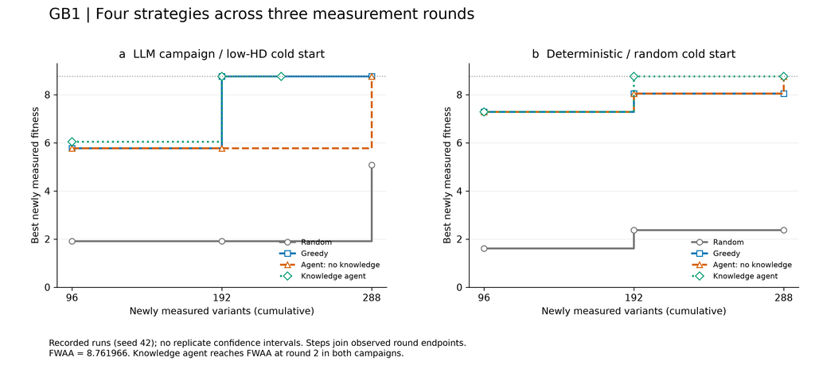

图 2：GB1 四位点定向进化四策略跨三轮累计最高适应度收敛曲线

**图 2（GB1 四策略跨三轮收敛曲线）**：四种策略在 3 轮实验（每轮 96 次，横轴累计查询数 96、192、288）中的新增测量累计最高适应度演进轨迹。野生型 WT（VDGV）参考适应度为 1.000，数据集中全量已测变体的理论最高峰值为 FWAA（8.761966）。知识增强智能体（绿色菱形虚线）与模型贪心（蓝色方形实线）均在第 2 轮（累计 192 次测定内）成功捕获真峰 FWAA；无知识智能体（橙色三角形虚线）延后至第 3 轮收敛；随机基线（灰色圆形实线）在第 3 轮仅达到 5.081244。

由系统底层 `campaign_llm.metrics.json` 与 `evidence/gb1_top10.csv` 导出的各轮次累计最高适应度及最终强变体产出统计见表 3：

**表 3：GB1 四策略跨三轮累计最高适应度与强变体产出收敛统计**

| 策略类别 | 第 1 轮最高值 | 第 2 轮最高值 | 第 3 轮最高值 | 累计命中强变体数 (Fitness>1.0) / 288 | 首次达峰轮次 |
| --- | --- | --- | --- | --- | --- |
| **随机探索基线 (Random)** | 1.910588 | 1.910588 | 5.081244 | 7 条 | 未达理论峰 |
| **确定性模型贪心 (Greedy)** | 5.772032 | **8.761966** | 8.761966 | 154 条 | **第 2 轮** |
| **无知识智能体 (No Knowledge)** | 5.772032 | 5.772032 | **8.761966** | 176 条 | 第 3 轮 |
| **知识增强智能体 (Knowledge Agent)** | **6.042078** | **8.761966** | 8.761966 | 125 条 | **第 2 轮** |

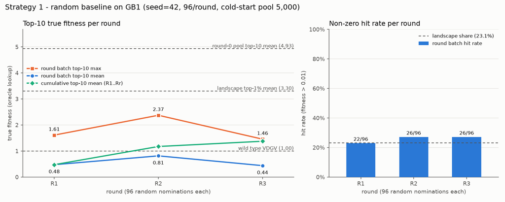

GB1 随机基线在不同轮次下的 Top-10 适应度分布与有效变体命中率

### 6.3 30-Seed 严格统计对照与极值 vs 强变体产出矛盾

为了排除单次随机种子运行的偶然性，我们在统一的 AAV2 实验协议下，对五种典型采集策略进行了 30 个随机种子（Seeds 0 至 29）的严格统计对照实验（每个种子独立运行 6 轮、每轮 48 条，总计 288 次测定）。

完整的实验统计矩阵见表 4（包含新增累计最高值、强变体产出数及达峰记录率）：

**表 4：AAV2 30-Seed 严格统计对照与极值 vs 强变体产出特征矩阵**

[output not shown]

*注：强变体判定阈值设定为全量 Clean 表的第 90 百分位数（$2.615913579904$），仅作为事后统一度量，不可线上透传。*

## 7 失败案例分析

### 7.1 失效案例一：无约束大模型发散与结构灭活风险

在系统的早期原型研发阶段（v0.1），我们曾设计过一个完全端到端的自主大语言模型智能体：允许 LLM 在仅阅读野生型基序和少量文字提示的前提下，自由发挥创造力并直接设计整条突变序列。

实验表明，完全无约束的端到端生成策略出现了明显的性能退化：

1. **突变发散与空间位阻冲突**：在缺乏底层门禁约束的情况下，LLM 生成的候选变体平均汉明距离上升至 $\overline{d_H} = 16.98$（在 28 残基窗口内突变比例超过 60%）。模型在非暴露位点引入较多芳香族大侧链（如 Trp、Tyr）或强电荷排斥残基，破坏了衣壳单体间的亚基相互作用界面；
2. **适应度大幅下降**：经 Oracle 测定，该批次候选序列的实测适应度均值降至 **−4.60**，大部分样本表现为包装失活；
3. **经验总结**：这一对比表明，在缺乏明确物理与理化约束的情况下，脱离数据分布的端到端生成易产生大量不可折叠或失活序列。物理与结构门禁是保证候选变体有效性、避免无效搜索的基础保障。

### 7.2 失效案例二：上位效应突变盲区与局部鞍点陷阱

在 AAV2 高突变文库探索中，贪心搜索算法易收敛于 7.8290 局部极值，未能跨越到 8.4162 峰值。通过对局部适应度景观与模型权重进行分析，可以归因于上位性突变盲区机制。

令 $A = \text{D0Q}$、$B = \text{S17E}$、$C = \text{V18A}$ 分别代表通向全局真峰的三单点突变，该局部子图在真实数据集中的实测标签与可识别性状态详见表 5。

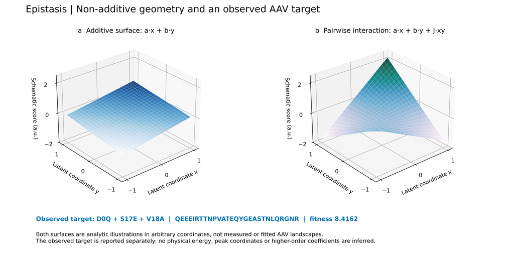

图 3：上位效应能量面几何与 AAV 目标位点非加性互作图谱

**图 3（上位效应能量面几何与非加性图谱）**：a，加性模型假设下的平面能量几何，任意位点的贡献相互独立，能量面为刚性超平面，无法形成局部曲率；b，引入成对上位性耦合项后形成的非线性二次曲面，呈现出典型的双曲鞍点（Saddle Point）特征；底部标注了未测池目标峰序列 ABC（D0Q+S17E+V18A，8.4162）。由于关键中间桥梁双突变体 AB 在初始库中天然缺测，导致代理模型在初期出现严重的上位性盲区，加性预测严重失真。

基于上述实测数据，我们可以展开清晰的数理推导： 若按照传统的单突变加性期望推算，ABC 的加性预测值为：
$$\begin{aligned}
\hat{f}_{\rm add}(ABC) &= f_A + f_B + f_C - 2 f_{\rm WT} \\
&= 0.302016 + 3.287418 + 0.889606 \\
&\quad - 2(-0.918194) \\
&= 6.315428
\end{aligned}$$
然而，ABC 的真实适应度高达 **8.416205**，其实际值比一阶加性期望整整高出了 **2.100777**！ 这一巨大的非线性增益究竟源自何处？在数学上，严格的三阶上位性差分定义为：
$$\begin{aligned}
\epsilon_{ABC} &= f_{ABC} - (f_{AB} + f_{AC} + f_{BC}) \\
&\quad + (f_A + f_B + f_C) - f_{\rm WT}
\end{aligned}$$
由于关键的中间过渡双突变体 $AB$ 在现实物理世界中从未被测定过（缺失值），导致三阶上位项 $\epsilon_{ABC}$ 在数学上是不可识别的（Unidentifiable）。

进一步分析表明：由于数据集中缺少 $AB$ 组合，在初始特征矩阵中关于 $A$ 与 $B$ 的成对交互列全为 0。在岭回归的 $L_2$ 正则化下，该权重被收缩为 0。这导致在探索初期，模型对目标峰 ABC 的预测均值仅为 6.3668，其在全池中的初始排序被低估至第 2,758 名（门禁内排名第 426 名）。 因此，基于纯均值的贪心算法在初期容易受到部分被高估候选变体的影响（门禁内 Top-48 候选预测均值达 11.31，但实测均值仅 2.88），收敛到局部鞍点而未对该盲区进行采样。而具备不确定性加权（如 UCB $\beta=3$）的机制能够在前期对高方差盲区进行主动探索，从而有助于跳出局部极值。

**表 5：AAV2 上位效应突变盲区局部子图实测适应度与证据层级**

[output not shown]

### 7.3 失效案例三：LLM 微观选样瓶颈与“探索税”定量测定

与之形成鲜明对比的是，底层的确定性数学公式（UCB $\beta=3$）在相同的 288 次预算下，展现出了稳定捕获 8.4162 的收敛轨迹。

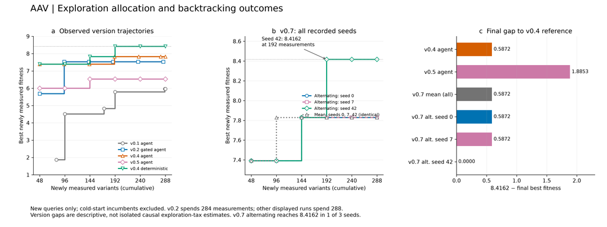

图 4：AAV 突变空间探索分配、版本轨迹与探索税定量测定

我们正式定义在固定预算 $T$ 下，确定性最优基线与智能体实际探索结果之间的性能差值为“**探索税**”（Exploration Tax）：
$$\begin{aligned}
\Delta_{\rm tax}(T) &= \max_{x \in S_{\rm UCB}(T)} f(x) - \max_{x
\in S_{\rm LLM}(T)} f(x) \\
&= 8.416205 - 7.828968 \\
&= \mathbf{0.587237} \approx \mathbf{0.5872}
\end{aligned}$$

对这 **0.5872** 性能差距的机理分析，反映了大语言模型在微观数值优化任务中的局限性：

1. **离散 Token 概率采样与微观微积分的失配**：LLM 本质上是在高维离散词元（Token）空间中基于自回归概率分布进行生成。在微观连续参数调优与高精度高阶曲面爬坡任务中，LLM 缺乏显式的一阶梯度（Gradient）与二阶海森矩阵（Hessian）曲率感知，其在局部鞍点附近的提报呈现出高频的随机抖动与注意力飘移；
2. **探索方差分配的次优性**：在微观选样时，LLM 往往难以精准计算每个候选残基对后验不确定性的贡献，容易将探索预算分配到信息增益有限的候选样本上，难以像贝叶斯优化置信界公式那样严格依据后验不确定性进行采样平衡；
3. **探索税测定的工程意义**：探索税的测定提供了一组客观的定量对比基准，明确了智能体系统的合理分工边界——在微观的连续数值采样中应充分依赖数学优化与代理模型，而将 LLM 的推理能力集中于上层假设生成、因果归因与实验方案调度。

## 8 改进建议与未来拓展

### 8.2 多目标帕累托前沿与高突变阶数工业挑战

在面向实际生物制造与药物设计的应用中，单一适应度的优化往往是不够的，通常需要同时权衡多个性质指标。

系统可进一步接入非支配排序遗传算法（NSGA-II）[[25]](https://doi.org/10.1109/4235.996017)等多目标优化算法，将候选序列的评价拓展为多目标向量：
$$\begin{aligned}
\mathbf{F}(x) = \Big( &f_{\rm activity}(x), \; f_{\rm stability}(x),
\\
&f_{\rm evasion}(x), \; f_{\rm yield}(x) \Big)^\top
\end{aligned}$$
系统不再输出单一最优标量解，而是求解高维性能空间中的非支配帕累托前沿解集（Pareto Optimal Set）：
$$\begin{aligned}
\mathcal{P} = \Big\{ x \in \mathcal{X} \;\Big|\; &\nexists x'
\in \mathcal{X}: \\
&\mathbf{F}(x') \succ \mathbf{F}(x) \Big\}
\end{aligned}$$
这也解释了为什么在复杂的蛋白质工程中往往需要探索高突变阶数——通过多位点的协同调控，才能在维持基本催化活性的同时，兼顾热稳定性、免疫逃逸及表达量等多维指标的帕累托平衡。

### 8.3 面向持续自演进科学发现的五机双循环架构（RSI 蓝图）

为了克服“固定脚本 + 简单提示工程”的架构局限，探索更具自适应能力的科学智能体系统，本研究设计了面向递归式自我完善（Recursive Self-Improvement, RSI）的“**五机双循环控制架构**”（Five-Machine Double-Loop Architecture）。

五大控制职责的具体设计如下：

1. **执行器（Executor）**：负责内环高频的日常实验交互，调用最新的代理模型、采集策略与门禁规则，驱动自动化变体生成与测序提名；
2. **验证器（Verifier）**：独立于执行器的只读审查机关，具备对物理契约、数据类型与安全红线的最高否决权；
3. **控制器（Controller）**：掌控全局预算分配、轮次流转与目标驱动停止契约的裁决；
4. **记忆器（Memory）**：将跨周期、跨实验积累的全部成功与失败经验，沉淀为结构化的可追溯事实账本（Fact Ledger）；
5. **改进器（Improver）**：在受控的影子沙箱（Shadow Sandbox）中，基于因果反事实推演，自主分析当前代理模型的表征短板，自主微调特征组合、探索参数乃至重写采集策略代码。所有策略改进需通过独立的回归验证门禁（Independent Regression Gate）后方可部署，以保证系统演进的稳定性与可控性。

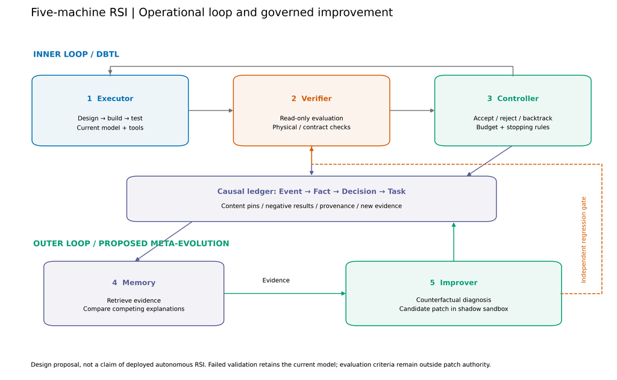

图 5：面向持续自演进科学发现的五机双循环架构与可控 RSI 演进蓝图

**图 5（五机双循环自演进架构与 RSI 演进蓝图）**：上方为高频运行的内环运维闭环（DBTL），包含执行器（Executor，负责生成与测试）、验证器（Verifier，只读物理审查）与控制器（Controller，预算与停止契约决策）；中间为核心中枢——基于可验证事件账本的因果知识库（Event → Fact → Decision → Task）；下方为低频深思的外环元进化闭环（Proposed Meta-Evolution），包含记忆器（Memory，证据归纳与假说检索）与改进器（Improver，在沙箱中进行反事实归因与策略自动重构）。虚线标识独立的回归验证门禁，防止自演进退化。

### 8.4 全新生成式设计模型扩展

本系统当前聚焦于固定候选序列池的搜索与排序，在未来的版本迭代中，系统将无缝接入最前沿的从头深度生成设计模型生态： - 利用 **ProteinMPNN**[[26]](https://doi.org/10.1126/science.add2187) 进行基于目标 3D 骨架构象的鲁棒氨基酸序列反向折叠设计； - 整合 **RFdiffusion**[[27]](https://doi.org/10.1038/s41586-023-06415-8) 与基于深度神经网络幻觉（Deep Network Hallucination）[[28]](https://doi.org/10.1038/s41586-021-04184-w) 的从头全新骨架生成技术，突破天然骨架的结构限制； - 融合大规模功能序列生成语言模型 **ProGen**[[29]](https://doi.org/10.1038/s41587-022-01618-2)，实现对跨物种广阔功能序列空间的自由采样。

### 8.5 自动化湿实验闭环（Self-Driving Lab / SiLA 2）愿景与可证伪研发路径

计算设计的最终验证依赖于物理实验。未来的科学智能体系统需要进一步与实验室自动化设备形成闭环。

结合自动驾驶实验室（Self-Driving Laboratories）前沿理念[[30]](https://doi.org/10.1016/j.trechm.2019.02.007)，系统规划通过国际通用的标准实验室自动化标准（SiLA 2，Standards in Laboratory Automation）总线协议，直接驱动高精度移液工作站（Liquid Handling Robots）、声波点样仪、菌落挑选仪与高通量微流控芯片，实现从“AI 假说提出 → 机器人自主合成质粒 → 细胞转染表达 → 高通量荧光/质谱测定 → 数据原子回传账本 → 算法下一轮进化”的全自动化无人自主科研闭环。

针对未来系统的工程研发，规划了五条条理清晰、职责解耦的可证伪研发流水线（Five Engineering Pipelines）：

1. **Pipeline 1: 数值优化内环流水线**：持续深耕确定性核方法、贝叶斯置信界与高效批次采样算法；
2. **Pipeline 2: 外环自反思与归因流水线**：研发具备自纠错、假说证伪与实验反思能力的元控制智能体；
3. **Pipeline 3: 覆盖度雷达与 3D 结构先验流水线**：将 AlphaFold2/3 构象能量与残基对缺测雷达全面融入采样启发式；
4. **Pipeline 4: 多目标帕累托前沿求解流水线**：构建面向高突变阶数的多表型高维非支配解集搜索器；
5. **Pipeline 5: 物理自动化实验接入流水线**：开发对接真实合成生物学生产线的 SiLA 2 驱动器与防污染回执审计系统。

### 参考文献

[1] YANG K K, WU Z, ARNOLD F H. Machine-learning-guided directed evolution for protein engineering[J]. Nature Methods, 2019, 16(8): 687-694. [原文](https://doi.org/10.1038/s41592-019-0496-6)

[2] STEMMER W P C. Rapid evolution of a protein in vitro by DNA shuffling[J]. Nature, 1994, 370(6488): 389-391. [原文](https://doi.org/10.1038/370389a0)

[3] REETZ M T, CARBALLEIRA J D. Iterative saturation mutagenesis (ISM) for rapid directed evolution of functional enzymes[J]. Nature Protocols, 2007, 2(4): 891-903. [原文](https://doi.org/10.1038/nprot.2007.72)

[4] WU N C, DAI L, OLSON C A, et al. Adaptation in protein fitness landscapes is facilitated by indirect paths[J]. eLife, 2016, 5: e16965. [原文](https://doi.org/10.7554/elife.16965)

[5] BRYANT D H, BASHIR A, SINAI S, et al. Deep diversification of an AAV capsid protein by machine learning[J]. Nature Biotechnology, 2021, 39(6): 691-696. [原文](https://doi.org/10.1038/s41587-020-00793-4)

[6] DALLAGO C, MOU J, JOHNSTON K E, et al. FLIP: Benchmark tasks in fitness landscape inference for proteins[C]//Proceedings of the Neural Information Processing Systems Track on Datasets and Benchmarks. 2021, 1. [原文](https://datasets-benchmarks-proceedings.neurips.cc/paper_files/paper/2021/file/2b44928ae11fb9384c4cf38708677c48-Paper-round2.pdf)

[7] NOTIN P, KOLLASCH A, RITTER D, et al. ProteinGym: Large-Scale Benchmarks for Protein Fitness Prediction and Design[C]//Advances in Neural Information Processing Systems. 2023, 36. [原文](https://proceedings.neurips.cc/paper_files/paper/2023/hash/cac723e5ff29f65e3fcbb0739ae91bee-Abstract-Datasets_and_Benchmarks.html)

[8] SARKISYAN K S, BOLOTIN D A, MEER M V, et al. Local fitness landscape of the green fluorescent protein[J]. Nature, 2016, 533(7603): 397-401. [原文](https://doi.org/10.1038/nature17995)

[9] HOERL A E, KENNARD R W. Ridge Regression: Biased Estimation for Nonorthogonal Problems[J]. Technometrics, 1970, 12(1): 55-67. [原文](https://doi.org/10.1080/00401706.1970.10488634)

[10] FRIEDMAN J H. Greedy function approximation: A gradient boosting machine[J]. The Annals of Statistics, 2001, 29(5): 1189-1232. [原文](https://doi.org/10.1214/aos/1013203451)

[11] WITTMANN B J, YUE Y, ARNOLD F H. Informed training set design enables efficient machine learning-assisted directed protein evolution[J]. Cell Systems, 2021, 12(11): 1026-1045.e7. [原文](https://doi.org/10.1016/j.cels.2021.07.008)

[12] RIVES A, MEIER J, SERCU T, et al. Biological structure and function emerge from scaling unsupervised learning to 250 million protein sequences[J]. Proceedings of the National Academy of Sciences, 2021, 118(15): e2016239118. [原文](https://doi.org/10.1073/pnas.2016239118)

[13] LIN Z, AKIN H, RAO R, et al. Evolutionary-scale prediction of atomic-level protein structure with a language model[J]. Science, 2023, 379(6637): 1123-1130. [原文](https://doi.org/10.1126/science.ade2574)

[14] BISWAS S, KHIMULYA G, ALLEY E C, et al. Low-N protein engineering with data-efficient deep learning[J]. Nature Methods, 2021, 18(4): 389-396. [原文](https://doi.org/10.1038/s41592-021-01100-y)

[15] FRAZER J, NOTIN P, DIAS M, et al. Disease variant prediction with deep generative models of evolutionary data[J]. Nature, 2021, 599(7883): 91-95. [原文](https://doi.org/10.1038/s41586-021-04043-8)

[16] HOPF T A, INGRAHAM J B, POELWIJK F J, et al. Mutation effects predicted from sequence co-variation[J]. Nature Biotechnology, 2017, 35(2): 128-135. [原文](https://doi.org/10.1038/nbt.3769)

[17] POELWIJK F J, SOCOLICH M, RANGANATHAN R. Learning the pattern of epistasis linking genotype and phenotype in a protein[J]. Nature Communications, 2019, 10(1): 4213. [原文](https://doi.org/10.1038/s41467-019-12130-8)

[18] SRINIVAS N, KRAUSE A, KAKADE S M, et al. Information-Theoretic Regret Bounds for Gaussian Process Optimization in the Bandit Setting[J]. IEEE Transactions on Information Theory, 2012, 58(5): 3250-3265. [原文](https://doi.org/10.1109/tit.2011.2182033)

[19] JONES D R, SCHONLAU M, WELCH W J. Efficient Global Optimization of Expensive Black-Box Functions[J]. Journal of Global Optimization, 1998, 13(4): 455-492. [原文](https://doi.org/10.1023/a:1008306431147)

[20] BRAN A M, COX S, SCHILTER O, et al. Augmenting large language models with chemistry tools[J]. Nature Machine Intelligence, 2024, 6(5): 525-535. [原文](https://doi.org/10.1038/s42256-024-00832-8)

[21] BOIKO D A, MACKNIGHT R, KLINE B, et al. Autonomous chemical research with large language models[J]. Nature, 2023, 624(7992): 570-578. [原文](https://doi.org/10.1038/s41586-023-06792-0)

[22] KING R D, ROWLAND J, OLIVER S G, et al. The Automation of Science[J]. Science, 2009, 324(5923): 85-89. [原文](https://doi.org/10.1126/science.1165620)

[23] HENIKOFF S, HENIKOFF J G. Amino acid substitution matrices from protein blocks[J]. Proceedings of the National Academy of Sciences, 1992, 89(22): 10915-10919. [原文](https://doi.org/10.1073/pnas.89.22.10915)

[24] JUMPER J, EVANS R, PRITZEL A, et al. Highly accurate protein structure prediction with AlphaFold[J]. Nature, 2021, 596(7873): 583-589. [原文](https://doi.org/10.1038/s41586-021-03819-2)

[25] DEB K, PRATAP A, AGARWAL S, et al. A fast and elitist multiobjective genetic algorithm: NSGA-II[J]. IEEE Transactions on Evolutionary Computation, 2002, 6(2): 182-197. [原文](https://doi.org/10.1109/4235.996017)

[26] DAUPARAS J, ANISHCHENKO I, BENNETT N, et al. Robust deep learning–based protein sequence design using ProteinMPNN[J]. Science, 2022, 378(6615): 49-56. [原文](https://doi.org/10.1126/science.add2187)

[27] WATSON J L, JUERGENS D, BENNETT N R, et al. De novo design of protein structure and function with RFdiffusion[J]. Nature, 2023, 620(7976): 1089-1100. [原文](https://doi.org/10.1038/s41586-023-06415-8)

[28] ANISHCHENKO I, PELLOCK S J, CHIDYAUSIKU T M, et al. De novo protein design by deep network hallucination[J]. Nature, 2021, 600(7889): 547-552. [原文](https://doi.org/10.1038/s41586-021-04184-w)

[29] MADANI A, KRAUSE B, GREENE E R, et al. Large language models generate functional protein sequences across diverse families[J]. Nature Biotechnology, 2023, 41(8): 1099-1106. [原文](https://doi.org/10.1038/s41587-022-01618-2)

[30] HÄSE F, ROCH L M, ASPURU-GUZIK A. Next-Generation Experimentation with Self-Driving Laboratories[J]. Trends in Chemistry, 2019, 1(3): 282-291. [原文](https://doi.org/10.1016/j.trechm.2019.02.007)